[O’Hara on GitHub](https://github.com/oharac)

# Rasterize EEZs, MEOWs, and Bathymetry

Compiled on Sun Jul 29 20:42:57 2018 by ohara

```r
knitr::opts_chunk$set(fig.width = 6, fig.height = 4, fig.path = 'Figs/',
                      echo = TRUE, message = FALSE, warning = FALSE)

library(raster)
library(sf)
source('https://raw.githubusercontent.com/oharac/src/master/R/common.R')


dir_git <- '~/github/spp_risk_dists'
dir_o_anx <- file.path(dir_O, 'git-annex/spp_risk_dists')

### project specific folders and info
source(file.path(dir_git, 'data_setup/common_fxns.R'))

### provenance tracking
# library(provRmd); prov_setup()


### Gall-Peters doesn't have an EPSG?
gp_proj4 <- '+proj=cea +lon_0=0 +lat_ts=45 +x_0=0 +y_0=0 +ellps=WGS84 +units=m +no_defs'
```

# 1 Summary

Set up analysis rasters for EEZs, MEOWs, and bathymetry at Gall-Peters 10 km^2 resolution.

# 2 Methods

## 2.1 EEZ raster

Using the OHI global EEZ shapefile, we will include all EEZs by OHI region code, as well as FAO regions and Antarctica, using unique identifiers. This will allow for separation by high seas vs. EEZ, or different takes on IUCN regional assessments using FAO or EEZ identifiers.

EEZ is rasterized for both land and sea, and then clipped to cells with non-NA values in the ocean_area raster. This ensures presence of more coastal cells with fractional ocean area coverage.

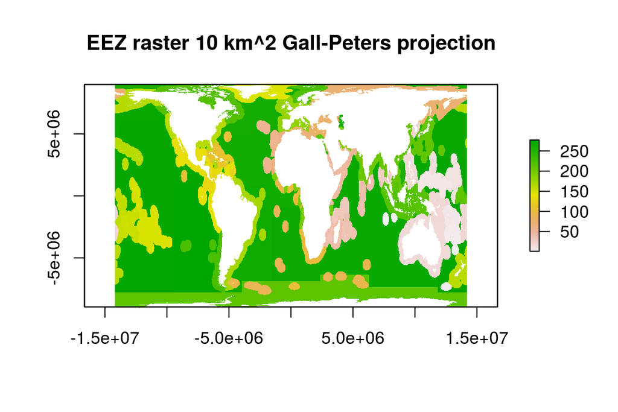

```r
eez_rast_file <- file.path(dir_git, 'spatial', 'eez_rast.tif')
eez_shp_file  <- file.path(dir_M, 'git-annex/globalprep/spatial/v2017/regions_2017_update.shp')

area_rast <- raster(file.path(dir_git, 'spatial', 'ocean_area_rast.tif'))
values(area_rast)[values(area_rast) <= .005] <- NA


if(!file.exists(eez_rast_file)) {
  eez_sf <- read_sf(eez_shp_file)

  eez_df <- eez_sf %>%
    as.data.frame() %>%
    dplyr::select(-geometry)
  eez_ids <- eez_df %>%
    select(rgn_id, rgn_name, rgn_ant_id) %>%
    distinct()
  ### rgn_ant_id is same as rgn_id except for Antarctica.  We don't really
  ### need to chunk out Antarctica at this point so just use rgn_id.
  ### Filter out all land polygons and project to Gall-Peters
  ### EDIT: don't filter out land; leave it in, then later mask using the
  ### area raster.  This should ensure more partial-ocean coastal cells are included.

  eez_sf_reclass <- eez_sf %>%
    clip_to_globe() %>%
    ### in common_fxn.R: ensures no coordinates outside +-180, +-90
    select(rgn_id, geometry) %>%
    st_transform(gp_proj4)

  # plot(eez_sf_reclass)

  rast_base <- area_rast

  eez_rast <- fasterize::fasterize(eez_sf_reclass, rast_base,
                                   field = 'rgn_id', fun = 'min')

  eez_rast_ocean <- eez_rast %>%
    mask(area_rast)

  writeRaster(eez_rast_ocean, eez_rast_file, overwrite = TRUE)

} else {
  # git_prov(eez_shp_file, 'input')
  # git_prov(eez_rast_file, 'output')
  eez_rast_ocean <- raster::raster(eez_rast_file)
}

plot(eez_rast_ocean, main = 'EEZ raster 10 km^2 Gall-Peters projection')
```

## 2.2 MEOW raster

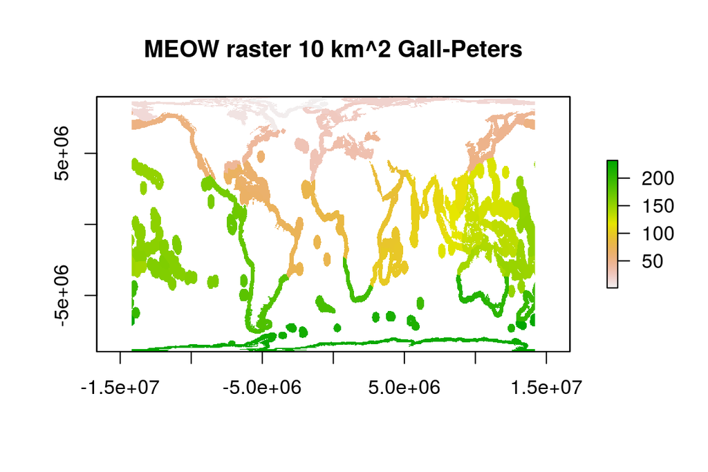

```r
meow_rast_file <- file.path(dir_git, 'spatial', 'meow_rast.tif')
meow_shp_file  <- file.path(dir_o_anx, 'meow/meow_ecos.shp')

if(!file.exists(meow_rast_file)) {
  meow_sf <- read_sf(meow_shp_file) %>%
    clip_to_globe()
    ### in common_fxn.R: ensures no coordinates outside +-180, +-90


  meow_sf_reclass <- meow_sf %>%
    select(ECO_CODE_X, geometry) %>%
    st_transform(gp_proj4)

  # plot(meow_sf_reclass)

  rast_base <- area_rast

  meow_rast <- fasterize::fasterize(meow_sf_reclass, rast_base,
                                   field = 'ECO_CODE_X', fun = 'min')

  meow_rast <- meow_rast %>%
    mask(area_rast)

  ### check whether there are shoreline gaps between MEOW maps and EEZ maps
  # x <- eez_rast
  # x[!is.na(values(meow_rast))] <- NA
  # plot(x)
  ### MEOWs seem to go inland to prevent shoreline gaps! yay

  writeRaster(meow_rast, meow_rast_file, overwrite = TRUE)
} else {
  # git_prov(meow_shp_file, 'input')
  # git_prov(meow_rast_file, 'output')
  meow_rast <- raster::raster(meow_rast_file)
}

plot(meow_rast, main = 'MEOW raster 10 km^2 Gall-Peters')
```

## 2.3 Bathymetry raster

Using [General Bathymetric Chart of the Oceans (GEBCO) bathymetry raster](https://www.bodc.ac.uk/data/hosted_data_systems/gebco_gridded_bathymetry_data/), identify min depth of ocean cells. For neritic and coastal cells, leaving as min depth allows for changing depth thresholds if desired. We will not clip based on anything below 200 m, so can classify these more coarsely.

NOTE: 1 arcmin and 30 arcsec are available; 30 arcsec is more recent but one arcmin should be sufficient for our purposes. Resample to 6 arc-minute (0.10°) using min depth in each cell.

Bathymetry is masked to the ocean area raster.

### 2.3.1 Create and view minimum depth raster

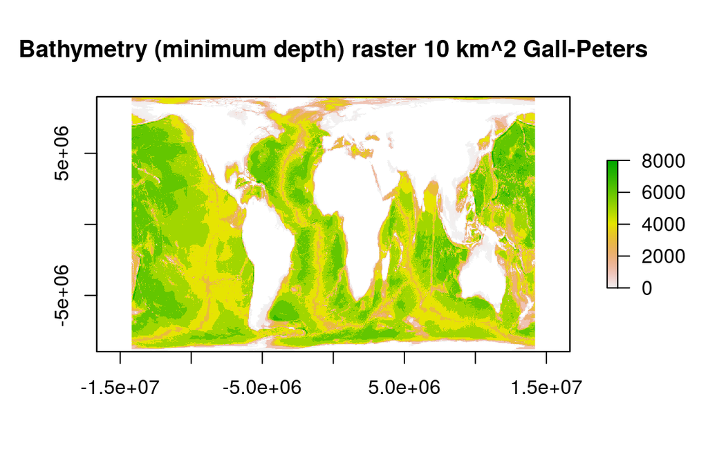

```r
bathy_rast_file <- file.path(dir_git, 'spatial', 'bathy_rast.tif')

gebco_rast_file <- file.path(dir_o_anx, 'gebco', 'GRIDONE_1D.nc')
gebco_rast_raw  <- raster(gebco_rast_file)

if(!file.exists(bathy_rast_file)) {
  ### The GEBCO raster is elevation, so depth is neg... for min depth,
  ### aggregate by max (and vice versa)
  bathy_rast_min <- gebco_rast_raw %>%
    raster::aggregate(fact = 6, fun = max)

  bathy_rast_min <- -1 * bathy_rast_min ### depth is positive

  rast_base <- area_rast

  bathy_rast_raw <- bathy_rast_min %>%
    projectRaster(rast_base,
                  progress = 'text',
                  method = 'ngb')

  ### reclassify:
  ### compress cells above zero to sea level;
  ### compress cells below 200 m to rough depth clips
  bathy_rast <- bathy_rast_raw
  values(bathy_rast)[values(bathy_rast_raw) < 0] <- 0
  values(bathy_rast)[values(bathy_rast_raw) > 200] <- 1000
  values(bathy_rast)[values(bathy_rast_raw) > 1000] <- 2000
  values(bathy_rast)[values(bathy_rast_raw) > 2000] <- 3000
  values(bathy_rast)[values(bathy_rast_raw) > 3000] <- 4000
  values(bathy_rast)[values(bathy_rast_raw) > 4000] <- 5000
  values(bathy_rast)[values(bathy_rast_raw) > 5000] <- 6000
  values(bathy_rast)[values(bathy_rast_raw) > 6000] <- 7000
  values(bathy_rast)[values(bathy_rast_raw) > 7000] <- 8000

  bathy_rast <- bathy_rast %>%
    mask(area_rast)

  writeRaster(bathy_rast, bathy_rast_file, overwrite = TRUE)

  rast_neritic <- rast_shallow <- bathy_rast
  values(rast_neritic) <- ifelse(values(bathy_rast) <= 200, 1, NA)
  values(rast_shallow) <- ifelse(values(bathy_rast) <=  60, 1, NA)

  writeRaster(rast_neritic, file.path(dir_git, 'spatial', 'bathy_rast_neritic.tif'),
              overwrite = TRUE)
  writeRaster(rast_shallow, file.path(dir_git, 'spatial', 'bathy_rast_shallow.tif'),
              overwrite = TRUE)

} else {
  # git_prov(bathy_rast_file, 'output')
  bathy_rast <- raster::raster(bathy_rast_file)
}

plot(bathy_rast, main = 'Bathymetry (minimum depth) raster 10 km^2 Gall-Peters')
```

```r
# prov_wrapup(commit_outputs = FALSE)
```